# hw2-buseaglar

2022-05-07

## 1. Introduction

The aim of this study is to model and forecast unleaded gasoline sales in a given quarter.The data used in this study includes quarterly gasoline and diesel sales (per 1000 m3) between 2000 and 2006. Based on these data, a forecast is made for 2007. In addition to the sales data, the values of the independent parameters that can affect the sales are also included in the data used.These independent variables are an index indicating the rate of new unleaded gasoline using vehicles being added to the traffic in a quarter (RNUV), average price (adjusted with an index) of a liter of unleaded gasoline in a quarter (PU), average price (adjusted with an index) of a liter of diesel gasoline in a quarter (PG), number of unleaded gasoline using vehicles in the traffic (NUGV), number of diesel gasoline using vehicles in the traffic (per 1000 people) (NDGV), agriculture component of Gross National Product (adjusted with an index) (GNPA), commerce component of Gross National Product (adjusted with an index) (GNPC), grand total for GNP (agriculture,and commerce and other components total) (GNP). In this study, concepts such as stationarity, autocorrelation, seasonality and trend that may have an impact on the regression model will be examined.

## 2. Analysis

The first thing to do before commenting on the data is to plot the time series.

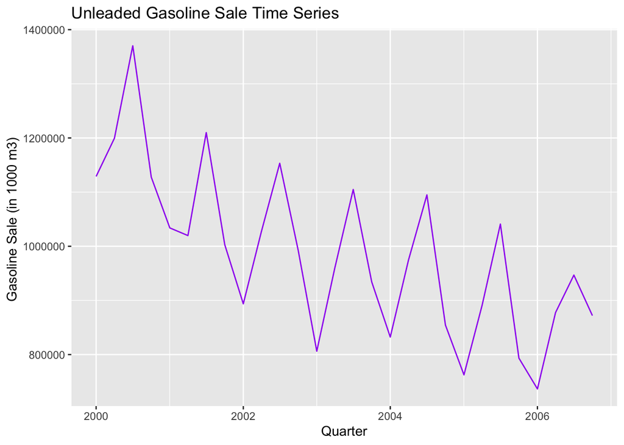

When the time series plot is examined, it is seen that there is a decreasing trend and there is a seasonality that shows similar characteristics every year.

### 2.1 Stationarity Analysis

In order for a time series to be stationary, statistical properties must not change over time. As can be seen in the plot, it is clear that this time series does not have a stationary mean, because it is a plot that decreases over time, and its mean also decreases. However, it is difficult to say the same for variance by looking at the graph because there is no obvious change. Rolling mean and rolling variance plots are drawn to make a clearer interpretation of stationarity.

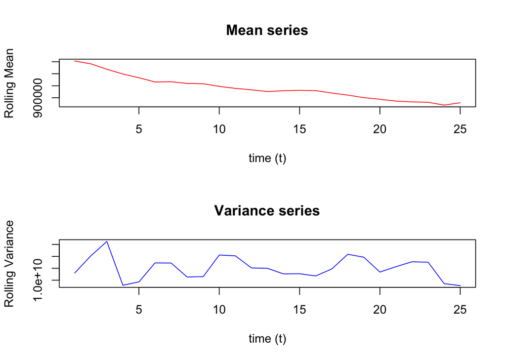

As can be seen in the graphs, the time series does not have a stationary mean, but it is possible to have a stationary variance.

### 2.2 Autocorrelation Analysis

Next is to examine autocorrelations by drawing lag-ACF plot. Autocorrelation measures the linear relationship between lagged values of a time series.

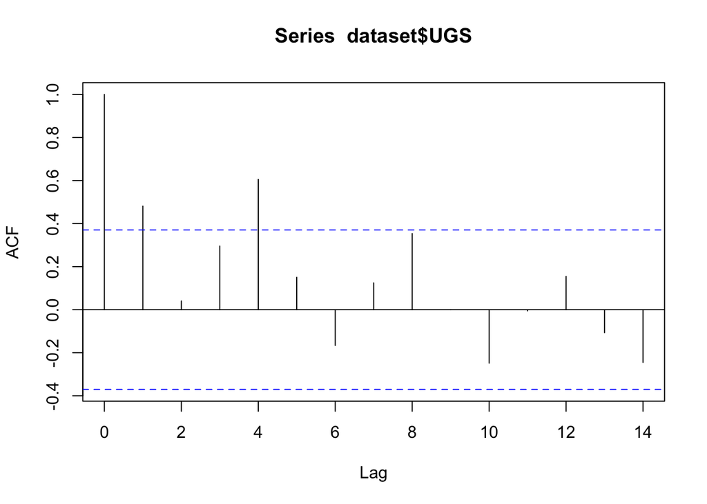

Also, another way to observe trend and seasonality is time series decomposition. The following decomposition of additive time series plot shows the trend and seasonality. Time series has a decreasing trend and an annual seasonality.

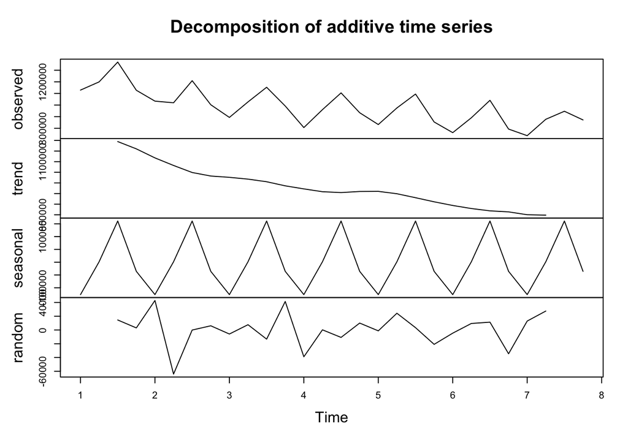

### 2.3 Regression Analysis

#### 2.3.1 Trend

As seen in the analysis above, the time series has a decreasing trend. Therefore, trend component should be added to the regression model.

```
##
## Call:
## lm(formula = UGS ~ trend, data = dataset)
##
## Residuals:
##     Min      1Q  Median      3Q     Max
## -199945  -73550  -21904   71224  237369
##
## Coefficients:
##             Estimate Std. Error t value Pr(>|t|)
## (Intercept)  1170777      43292  27.043  < 2e-16 ***
## trend         -12660       2608  -4.854 4.95e-05 ***
## ---
## Signif. codes:  0 '***' 0.001 '**' 0.01 '*' 0.05 '.' 0.1 ' ' 1
##
## Residual standard error: 111500 on 26 degrees of freedom
## Multiple R-squared:  0.4754, Adjusted R-squared:  0.4552
## F-statistic: 23.56 on 1 and 26 DF,  p-value: 4.945e-05
```

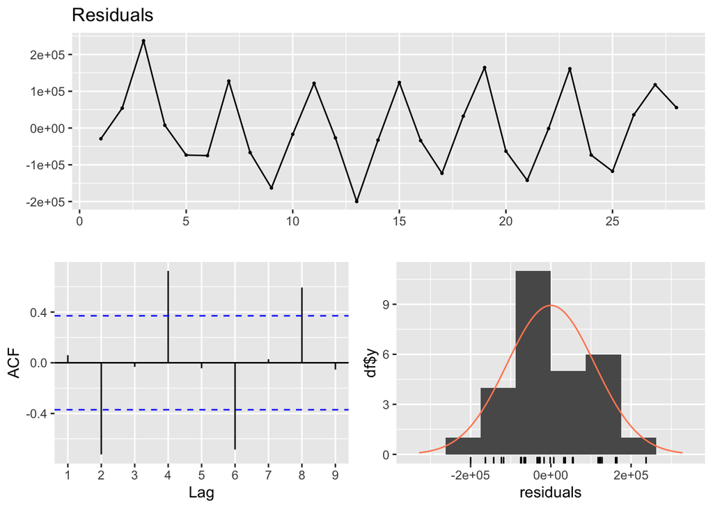

```
##
##  Breusch-Godfrey test for serial correlation of order up to 6
##
## data:  Residuals
## LM test = 19.942, df = 6, p-value = 0.002836
```

As seen above, the trend is a very significant parameter when the trend component is added to the regression model. However, the adjusted R-squared value is low and needs improvement. When the resudials are examined, it can be said that the normality assumption is satisfied. However, there is a very high autocorrelation especially in the 2,4,6, and 8th lags. This indicates that residuals have information that should be used when creating the model.

#### 2.3.2 Seasonality

It was seen in the reviews above that time series also has seasonality. Therefore, seasonality component needs to be added to the regression model.

```
##
## Call:
## lm(formula = UGS ~ trend + V2, data = dataset)
##
## Residuals:
##    Min     1Q Median     3Q    Max
## -81167 -31283  -3458  28640  94502
##
## Coefficients:
##             Estimate Std. Error t value Pr(>|t|)
## (Intercept)  1060372      23653  44.830  < 2e-16 ***
## trend         -13497       1147 -11.764 3.28e-11 ***
## V22           121532      25987   4.677 0.000104 ***
## V23           273618      26063  10.498 3.03e-10 ***
## V24            95049      26189   3.629 0.001405 **
## ---
## Signif. codes:  0 '***' 0.001 '**' 0.01 '*' 0.05 '.' 0.1 ' ' 1
##
## Residual standard error: 48570 on 23 degrees of freedom
## Multiple R-squared:  0.9119, Adjusted R-squared:  0.8966
## F-statistic: 59.53 on 4 and 23 DF,  p-value: 8.446e-12
```

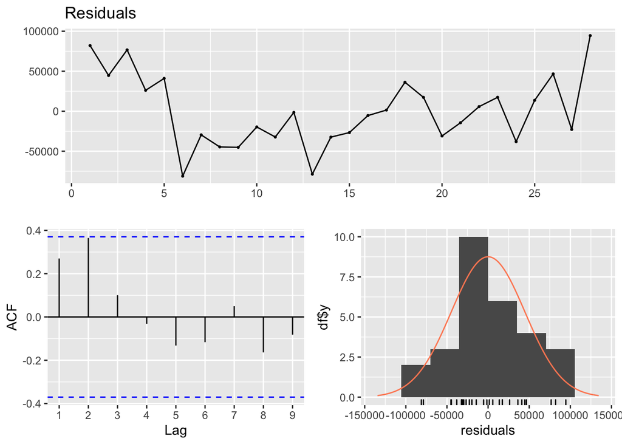

```
##
##  Breusch-Godfrey test for serial correlation of order up to 8
##
## data:  Residuals
## LM test = 11.462, df = 8, p-value = 0.1769
```

By making some data manipulations, the seasonality component is added and the above model is obtained. Again, all parameters are quite significant. In addition, the Adjusted R-squared value has also improved over the first model. When the residuals are examined, it is seen that there is no big problem. Autocorrelations decreased, normality assumption is achieved and zero mean is observed.

#### 2.3.3 Lagged Variable

Lagged variables can also be added to the model to create a good model. Lagged 1 values are added to the data by some data manipulation and its effect on the model is examined.

```
##
## Call:
## lm(formula = UGS ~ trend + V2 + lag1, data = dataset)
##
## Residuals:
##    Min     1Q Median     3Q    Max
## -87046 -18851   2692  19111  90358
##
## Coefficients:
##               Estimate Std. Error t value Pr(>|t|)
## (Intercept)  6.464e+05  2.496e+05   2.590   0.0171 *
## trend       -8.004e+03  3.241e+03  -2.470   0.0222 *
## V22          1.627e+05  2.990e+04   5.441 2.13e-05 ***
## V23          2.732e+05  2.612e+04  10.457 8.80e-10 ***
## V24          4.278e+04  4.830e+04   0.886   0.3858
## lag1         3.344e-01  2.132e-01   1.569   0.1317
## ---
## Signif. codes:  0 '***' 0.001 '**' 0.01 '*' 0.05 '.' 0.1 ' ' 1
##
## Residual standard error: 44080 on 21 degrees of freedom
##   (1 observation deleted due to missingness)
## Multiple R-squared:  0.9314, Adjusted R-squared:  0.9151
## F-statistic: 57.06 on 5 and 21 DF,  p-value: 1.651e-11
```

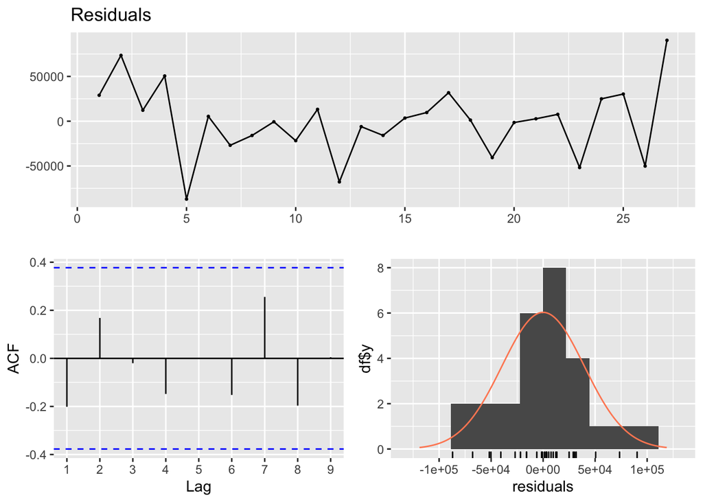

```
##
##  Breusch-Godfrey test for serial correlation of order up to 9
##
## data:  Residuals
## LM test = 10.208, df = 9, p-value = 0.3339
```

The adjusted R-squared value improved and autocorrelations further decreased. However, lagged values are not seen as significant in the model.

#### 2.3.4 Independent Variables

Finally, the regression model can be improved with independent variables and better forecast can be made.The figure below is created to examine the correlation between the sales values of 9 independent variables.

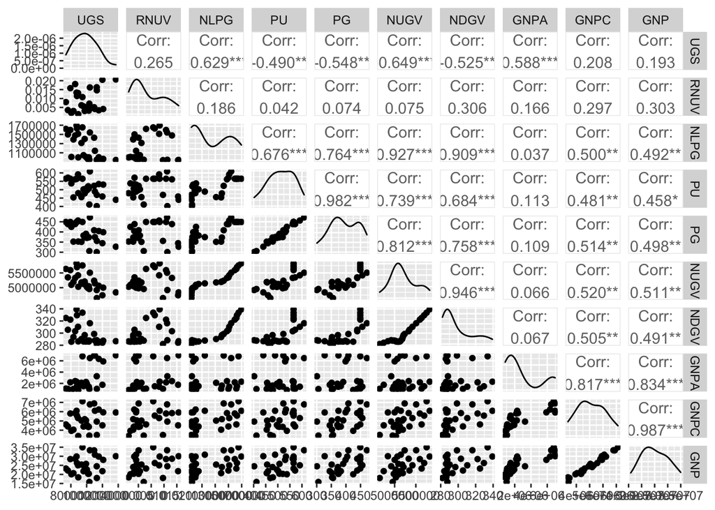

From the figure, it is seen that the UGS, which is the target variable, has a significant correlation with NLPG, PU, PG, NUGV, NDGV, GNPA. I will add them to the latest model one by one and see if they contribute to the model.

```
##
## Call:
## lm(formula = UGS ~ trend + V2 + lag1 + NLPG, data = dataset)
##
## Residuals:
##    Min     1Q Median     3Q    Max
## -79183 -17969     18  15545  86513
##
## Coefficients:
##               Estimate Std. Error t value Pr(>|t|)
## (Intercept)  8.445e+05  2.434e+05   3.469 0.002422 **
## trend       -2.298e+04  7.168e+03  -3.206 0.004434 **
## V22          1.339e+05  3.001e+04   4.463 0.000239 ***
## V23          2.895e+05  2.486e+04  11.645 2.31e-10 ***
## V24          1.086e+05  5.256e+04   2.066 0.052059 .
## lag1        -1.913e-02  2.481e-01  -0.077 0.939300
## NLPG         2.913e-01  1.270e-01   2.293 0.032791 *
## ---
## Signif. codes:  0 '***' 0.001 '**' 0.01 '*' 0.05 '.' 0.1 ' ' 1
##
## Residual standard error: 40190 on 20 degrees of freedom
##   (1 observation deleted due to missingness)
## Multiple R-squared:  0.9457, Adjusted R-squared:  0.9294
## F-statistic: 58.07 on 6 and 20 DF,  p-value: 1.325e-11
```

```
##
## Call:
## lm(formula = UGS ~ trend + V2 + lag1 + PU, data = dataset)
##
## Residuals:
##    Min     1Q Median     3Q    Max
## -59596 -21821  -3340  22518  86321
##
## Coefficients:
##               Estimate Std. Error t value Pr(>|t|)
## (Intercept)  9.996e+05  2.777e+05   3.600  0.00179 **
## trend       -6.794e+03  3.017e+03  -2.252  0.03573 *
## V22          1.644e+05  2.740e+04   5.998 7.28e-06 ***
## V23          2.905e+05  2.515e+04  11.553 2.65e-10 ***
## V24          6.362e+04  4.521e+04   1.407  0.17472
## lag1         2.253e-01  2.012e-01   1.120  0.27618
## PU          -5.319e+02  2.373e+02  -2.242  0.03646 *
## ---
## Signif. codes:  0 '***' 0.001 '**' 0.01 '*' 0.05 '.' 0.1 ' ' 1
##
## Residual standard error: 40380 on 20 degrees of freedom
##   (1 observation deleted due to missingness)
## Multiple R-squared:  0.9452, Adjusted R-squared:  0.9288
## F-statistic: 57.51 on 6 and 20 DF,  p-value: 1.452e-11
```

```
##
## Call:
## lm(formula = UGS ~ trend + V2 + lag1 + PG, data = dataset)
##
## Residuals:
##    Min     1Q Median     3Q    Max
## -69592 -21731  -3796  24011  85714
##
## Coefficients:
##               Estimate Std. Error t value Pr(>|t|)
## (Intercept)  9.366e+05  2.720e+05   3.443  0.00257 **
## trend       -5.704e+03  3.219e+03  -1.772  0.09162 .
## V22          1.640e+05  2.785e+04   5.890 9.24e-06 ***
## V23          2.879e+05  2.536e+04  11.353 3.59e-10 ***
## V24          5.775e+04  4.556e+04   1.267  0.21955
## lag1         2.593e-01  2.018e-01   1.285  0.21346
## PG          -6.543e+02  3.185e+02  -2.054  0.05327 .
## ---
## Signif. codes:  0 '***' 0.001 '**' 0.01 '*' 0.05 '.' 0.1 ' ' 1
##
## Residual standard error: 41040 on 20 degrees of freedom
##   (1 observation deleted due to missingness)
## Multiple R-squared:  0.9434, Adjusted R-squared:  0.9264
## F-statistic: 55.54 on 6 and 20 DF,  p-value: 2.009e-11
```

```
##
## Call:
## lm(formula = UGS ~ trend + V2 + lag1 + NUGV, data = dataset)
##
## Residuals:
##    Min     1Q Median     3Q    Max
## -93294 -20110   5309  17702  79269
##
## Coefficients:
##               Estimate Std. Error t value Pr(>|t|)
## (Intercept)  2.816e+05  5.736e+05   0.491   0.6289
## trend       -1.133e+04  5.722e+03  -1.979   0.0617 .
## V22          1.607e+05  3.040e+04   5.285 3.58e-05 ***
## V23          2.734e+05  2.644e+04  10.339 1.80e-09 ***
## V24          4.498e+04  4.898e+04   0.918   0.3694
## lag1         3.080e-01  2.189e-01   1.407   0.1749
## NUGV         8.440e-02  1.192e-01   0.708   0.4869
## ---
## Signif. codes:  0 '***' 0.001 '**' 0.01 '*' 0.05 '.' 0.1 ' ' 1
##
## Residual standard error: 44610 on 20 degrees of freedom
##   (1 observation deleted due to missingness)
## Multiple R-squared:  0.9331, Adjusted R-squared:  0.9131
## F-statistic: 46.51 on 6 and 20 DF,  p-value: 1.042e-10
```

```
##
## Call:
## lm(formula = UGS ~ trend + V2 + lag1 + NDGV, data = dataset)
##
## Residuals:
##    Min     1Q Median     3Q    Max
## -92018 -20517   4752  23704  60200
##
## Coefficients:
##               Estimate Std. Error t value Pr(>|t|)
## (Intercept)  3.298e+05  2.975e+05   1.109 0.280752
## trend       -1.455e+04  4.815e+03  -3.022 0.006736 **
## V22          1.436e+05  3.046e+04   4.715 0.000133 ***
## V23          2.768e+05  2.497e+04  11.086 5.44e-10 ***
## V24          7.389e+04  4.925e+04   1.500 0.149147
## lag1         1.428e-01  2.301e-01   0.621 0.541781
## NDGV         2.008e+03  1.133e+03   1.772 0.091675 .
## ---
## Signif. codes:  0 '***' 0.001 '**' 0.01 '*' 0.05 '.' 0.1 ' ' 1
##
## Residual standard error: 41990 on 20 degrees of freedom
##   (1 observation deleted due to missingness)
## Multiple R-squared:  0.9407, Adjusted R-squared:  0.923
## F-statistic: 52.92 on 6 and 20 DF,  p-value: 3.154e-11
```

```
##
## Call:
## lm(formula = UGS ~ trend + V2 + lag1 + GNPA, data = dataset)
##
## Residuals:
##    Min     1Q Median     3Q    Max
## -73863 -20439  -5558  19904  88297
##
## Coefficients:
##               Estimate Std. Error t value Pr(>|t|)
## (Intercept)  8.712e+05  2.972e+05   2.932  0.00825 **
## trend       -1.126e+04  4.006e+03  -2.811  0.01080 *
## V22          1.156e+05  4.588e+04   2.519  0.02041 *
## V23         -3.478e+03  2.085e+05  -0.017  0.98685
## V24          1.857e+04  5.075e+04   0.366  0.71823
## lag1         9.760e-02  2.741e-01   0.356  0.72551
## GNPA         5.069e-02  3.790e-02   1.337  0.19612
## ---
## Signif. codes:  0 '***' 0.001 '**' 0.01 '*' 0.05 '.' 0.1 ' ' 1
##
## Residual standard error: 43270 on 20 degrees of freedom
##   (1 observation deleted due to missingness)
## Multiple R-squared:  0.9371, Adjusted R-squared:  0.9182
## F-statistic: 49.64 on 6 and 20 DF,  p-value: 5.714e-11
```

After examining all the models, I found that adding the NLPG independent variable worked best. However, lag 1 appears to be not significant in the model. The adjusted R-squared value improved when I removed lag 1 from the model.Therefore, I will continue the model with trend, seasonality and NLPG.

### 2.4 Final Analysis

```
##
## Call:
## lm(formula = UGS ~ trend + V2 + NLPG, data = dataset)
##
## Residuals:
##    Min     1Q Median     3Q    Max
## -83022 -23287   3235  18555  90847
##
## Coefficients:
##               Estimate Std. Error t value Pr(>|t|)
## (Intercept)  8.082e+05  7.363e+04  10.977 2.16e-10 ***
## trend       -2.422e+04  3.163e+03  -7.657 1.21e-07 ***
## V22          1.286e+05  2.128e+04   6.044 4.40e-06 ***
## V23          2.824e+05  2.140e+04  13.200 6.24e-12 ***
## V24          9.835e+04  2.137e+04   4.601 0.000139 ***
## NLPG         3.259e-01  9.184e-02   3.549 0.001800 **
## ---
## Signif. codes:  0 '***' 0.001 '**' 0.01 '*' 0.05 '.' 0.1 ' ' 1
##
## Residual standard error: 39600 on 22 degrees of freedom
## Multiple R-squared:  0.944,  Adjusted R-squared:  0.9313
## F-statistic: 74.15 on 5 and 22 DF,  p-value: 5.077e-13
```

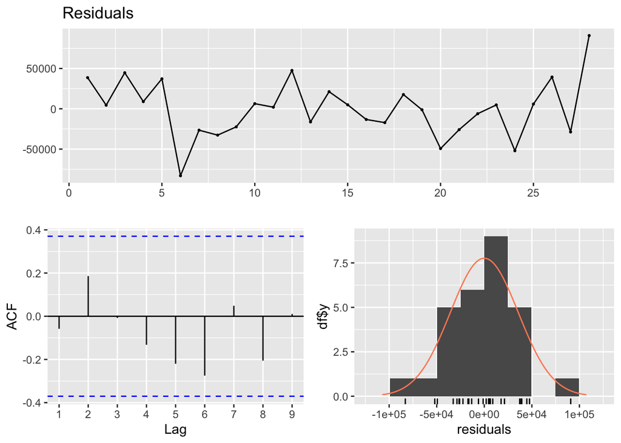

```
##
##  Breusch-Godfrey test for serial correlation of order up to 9
##
## data:  Residuals
## LM test = 13.521, df = 9, p-value = 0.1404
```

The adjusted R-square of my last model is 0.9313. It can be said to be a good model since it is an improved value compared to my previous models and is close to 1 in general. Also, all coefficients are quite significant. In other words, they are related to the UGS we want to model and they are all parameters that increase the power of the model. If we look at residuals, the autocorrelations seem to be low. The normality assumption of the residuals is also provided. In general, it can be said that this model is a good model.

## 3. Predictions

I made the forecast using the last model. My predictions for unleaded gasoline sales for 2007 are as follows:

```
## [1] 664776.7 772560.4 910520.7 717322.3
```